# Chapter 3 - Exploratory Data Analysis

Stephen Roecker and Tom D’Avello

2021-02-03

# Objectives

- Review methods for estimating Low, RV, and High values
- Review different methods for visualing soil data

# Range in Characteristics (RIC)

- Why does the L, RV, and H clay represent?
  - What taxonomic unit do they refer too?
- What is the L and H for texture?

| hzname | clay_l | clay_r | clay_h | texture |
| --- | --- | --- | --- | --- |
| Ap | 7 | 18 | 26.1 | sil |
| Bt1 | 24 | 27 | 35.0 | sicl |
| 2Bt2 | 27 | 31 | 35.0 | cl |
| 2BCt | 15 | 22 | 25.0 | l |
| 2Cd | 10 | 15 | 20.0 | l |

# Descriptive Statistics - Estimates of L, RV & H

| Parameter | NASIS | Description | R function |
| --- | --- | --- | --- |
| Mean | RV | arithmetic average | mean() |
| Median | RV | middle value, 50% quantile | median() |
| Mode | RV | most frequent value | sort(table(), decreasting = TRUE)[1] |
| Standard Deviation | L & H | variation | sd() |
| Quantiles | L & H | percent rank of values, such that all values are <= p | quantile() |

# Descriptive Statistics - Numeric Data

```r
data("loafercreek")
h <- horizons(loafercreek)
h$texture_class <- factor(h$texture_class)

h %>%
  select(clay, phfield, total_frags_pct, texture_class) %>%
  summary()
```

```
##       clay          phfield     total_frags_pct texture_class
##  Min.   :10.00   Min.   :4.90   Min.   : 0.00   l      :265
##  1st Qu.:18.00   1st Qu.:6.00   1st Qu.: 0.00   br     :105
##  Median :22.00   Median :6.30   Median : 5.00   cl     :101
##  Mean   :23.63   Mean   :6.18   Mean   :13.88   sil    : 56
##  3rd Qu.:28.00   3rd Qu.:6.50   3rd Qu.:20.00   spm    : 22
##  Max.   :60.00   Max.   :7.00   Max.   :95.00   (Other): 52
##  NA's   :167     NA's   :381                    NA's   : 25
```

# Descriptive Statistics - Categorical Data

```r
table(h$genhz, h$texture_class, useNA = "ifany")
```

```
##
##        br  c cb cl gr  l pg scl sic sicl sil sl spm <NA>
##   2BCt  0  6  0  3  0  0  0   0   0    0   0  0   0    0
##   2Bt   0  5  0  1  0  0  0   0   0    0   0  0   0    0
##   A     0  0  0  1  0 97  0   0   0    1  29  7   0    3
##   BA    0  0  0  0  0  2  0   0   0    0   0  0   0    0
##   BCt   0  2  0  8  0  7  0   1   0    1   1  0   0    1
##   Bt    0  0  0 17  0 37  0   0   0    0   1  1   0    0
##   Bt1   0  1  0 13  0 57  0   3   0    1  12  0   0    2
##   Bt2   0  4  0 40  0 45  0   4   2    6   8  0   0    0
##   Bt3   0  0  0  6  0  2  0   0   0    0   0  0   0    0
##   Cr   55  1  1  1  3  1  1   1   0    0   0  0   0   10
##   Oi    0  0  0  0  0  0  0   0   0    0   0  0   4    0
##   R    43  0  0  0  0  0  0   0   0    0   0  0   0    2
##   <NA>  7  0  0 11  0 17  0   0   0    0   5  0  18    7
```

# Data Inspection - Missing Data

1. **Exclude** all rows or columns that contain missing values using the function `na.exclude()`, such as `h2 <- na.exclude(h)`. However this can be wasteful because it removes all rows (e.g., horizons), regardless if the row only has 1 missing value. Instead it’s sometimes best to create a temporary copy of the variable in question and then remove the missing variables, such as `clay <- na.exclude(h$clay)`.
2. **Replace** missing values with another value, such as zero, a global constant, or the mean or median value for that column, such as `h$clay <- ifelse(is.na(h$clay), 0, h$clay) # or h[is.na(h$clay), ] <- 0`.
3. **Read** the help file for the function you’re attempting to use. Many functions have additional arguments for dealing with missing values, such as `na.rm`.

# Graphical Methods - Descriptions

| Plot Types | Description |
| --- | --- |
| Bar | a plot where each bar represents the frequency of observations for a ‘group’ |
| Histogram | a plot where each bar represents the frequency of observations for a ‘given range of values’ |
| Density | an estimation of the frequency distribution based on the sample data |
| Quantile-Quantile | a plot of the actual data values against a normal distribution |
| Box-Whisker | a visual representation of median, quartiles, symmetry, skewness, and outliers |
| Scatter & Line | a graphical display of one variable plotted on the x axis and another on the y axis |

# Graphical Methods - Functions

| Plot Types | Base R | lattice | ggplot geoms |
| --- | --- | --- | --- |
| Bar | barplot() | barchart() | geom_bar() |
| Histogram | hist() | histogram() | geom_histogram() |
| Density | plot(density()) | densityplot() | geom_density() |
| Quantile-Quantile | qqnorm() | qq() | geom_qq() |
| Box-Whisker | boxplot() | bwplot() | geom_boxplot() |
| Scatter & Line | plot() | xyplot | geom_point() |

# Distributions

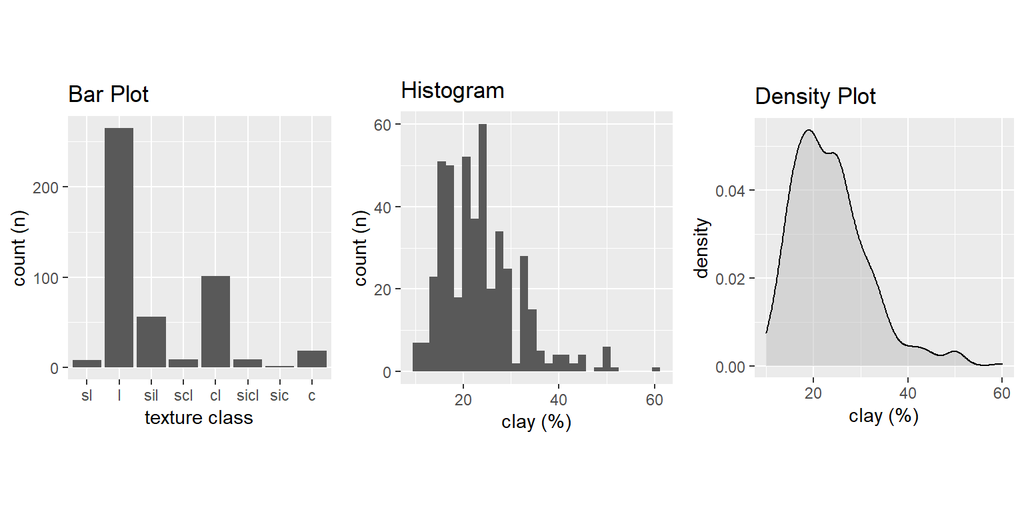

# The ’Normal Distribution

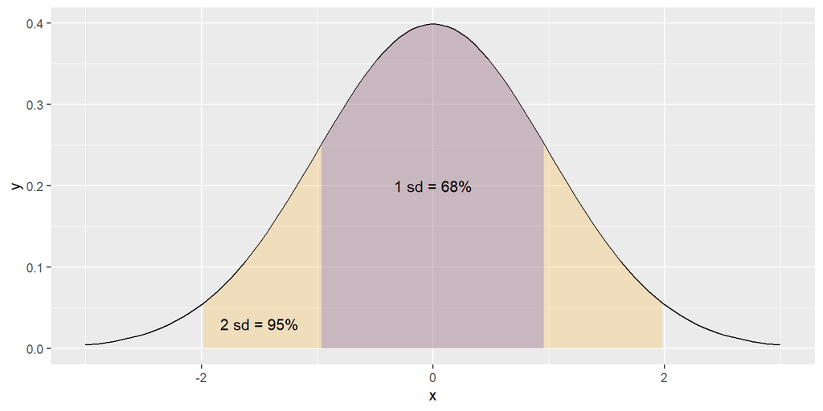

# Mean & SD vs Median & Quantiles

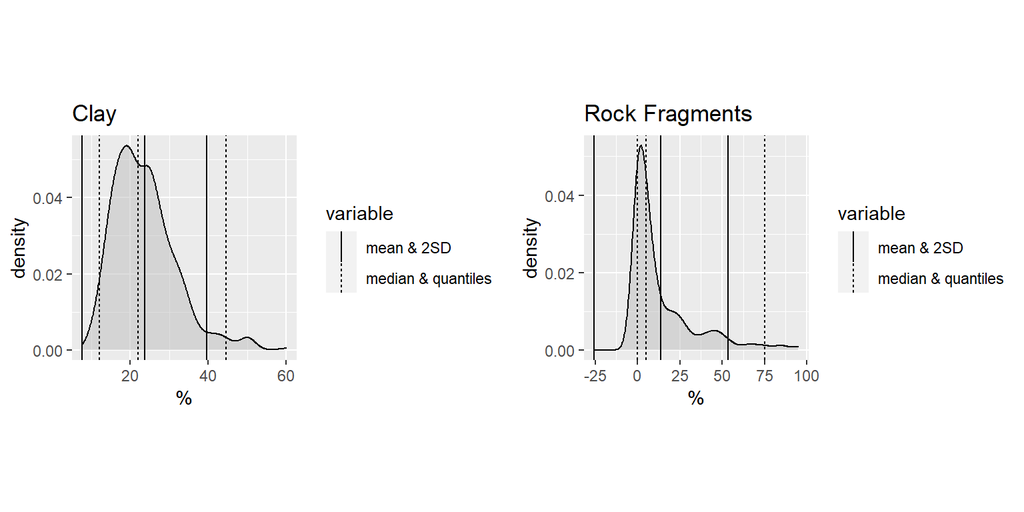

# Distributions

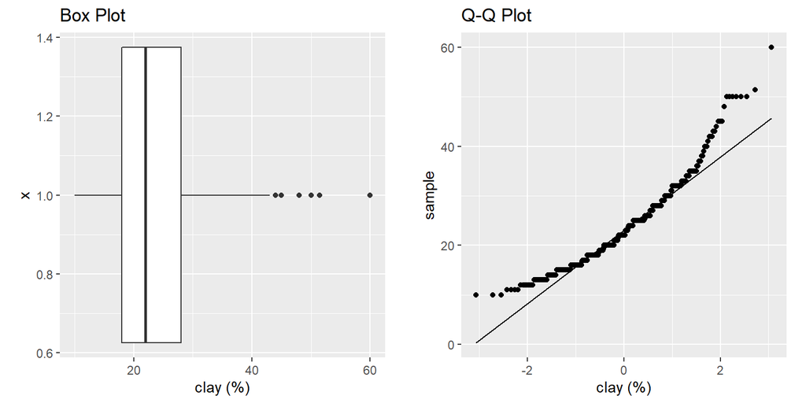

# Relationships

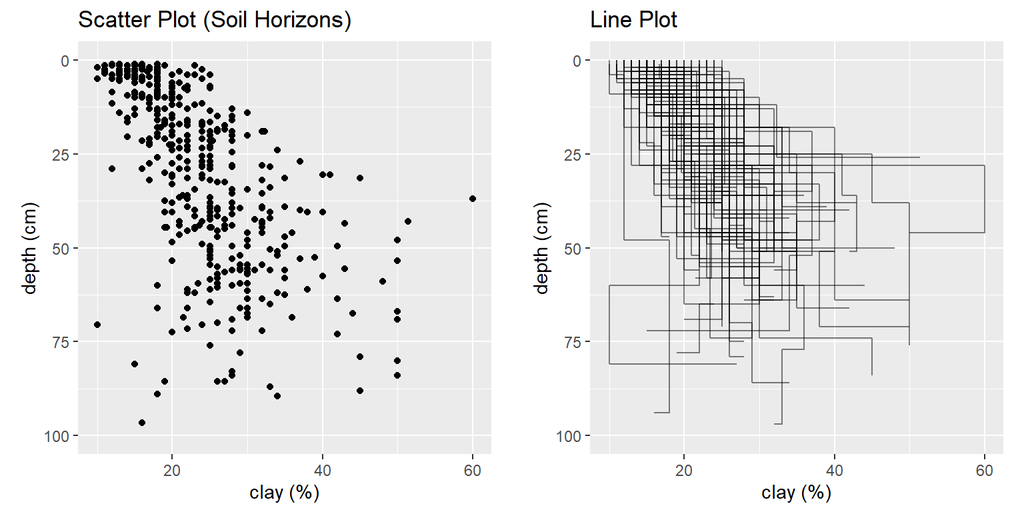

# 3rd Dimension - Color, Shape, Size, Layers, etc…

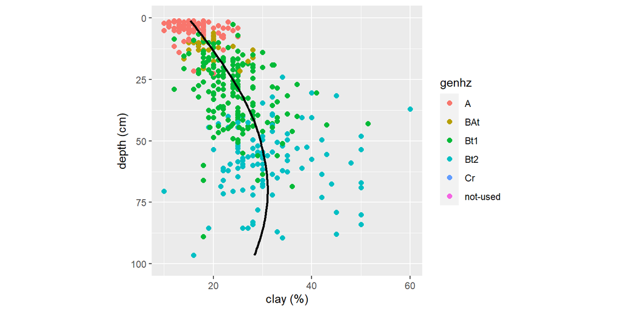

# 3rd Dimension - Color

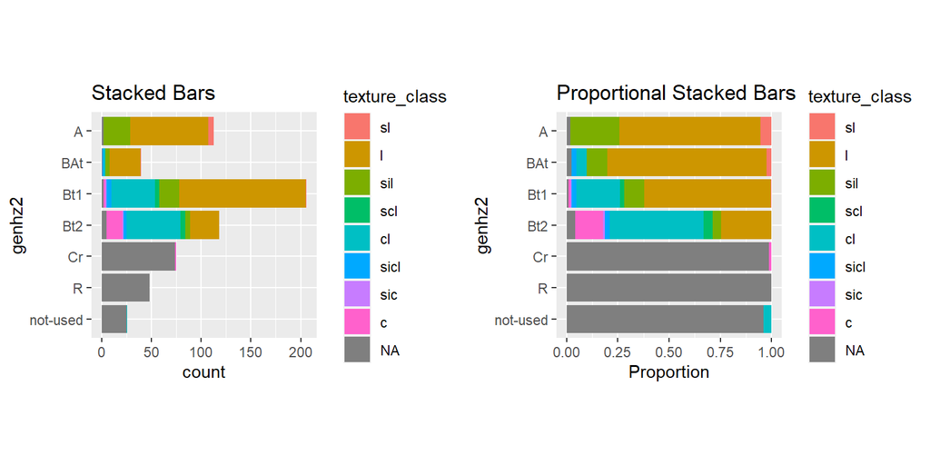

# 3rd Dimension - Groups

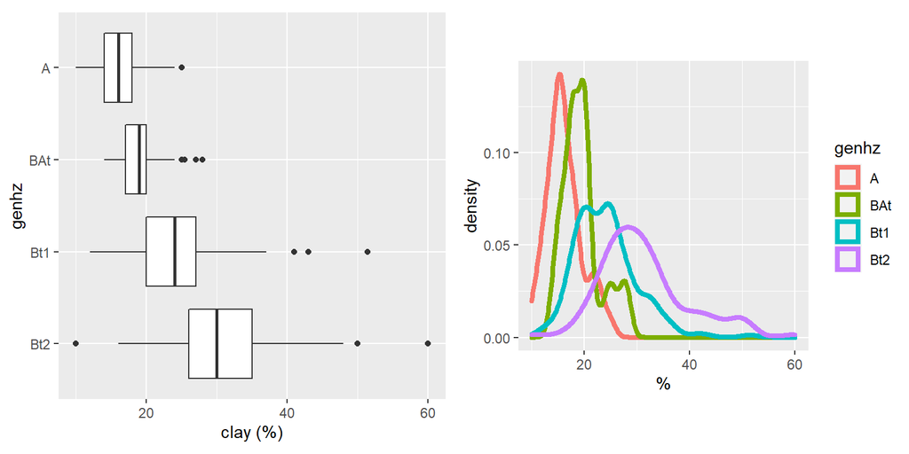

# 3rd Dimension - Facets

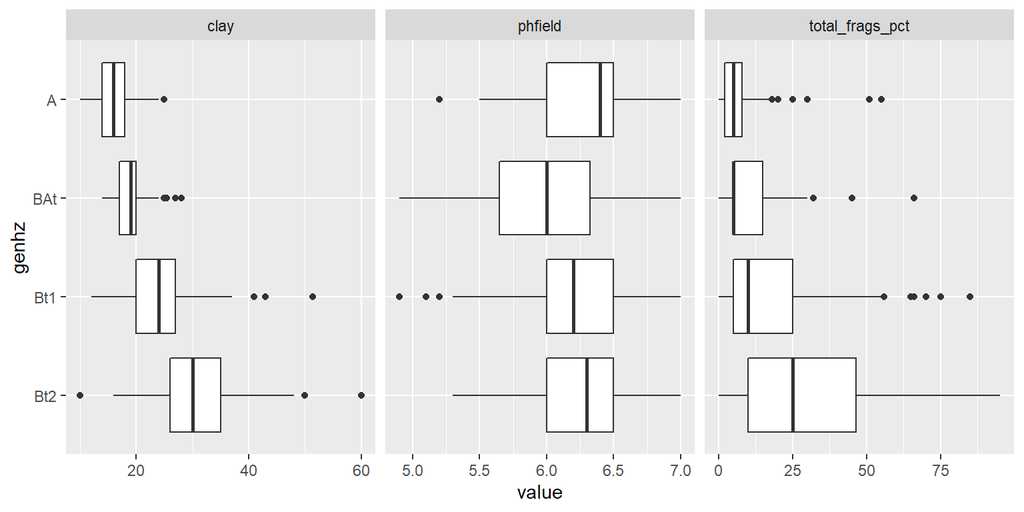

# 3rd Dimension - Facets

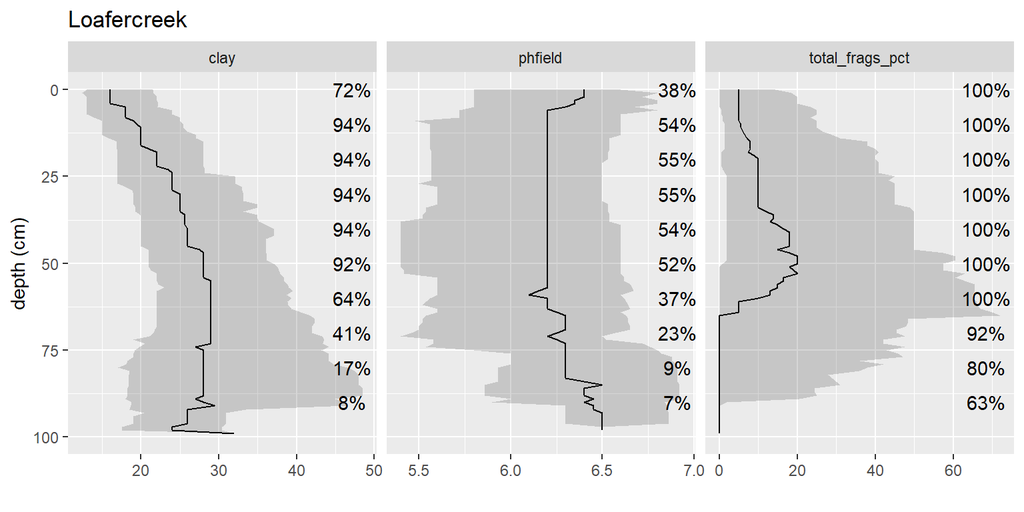

# 3rd Dimension - Correlation

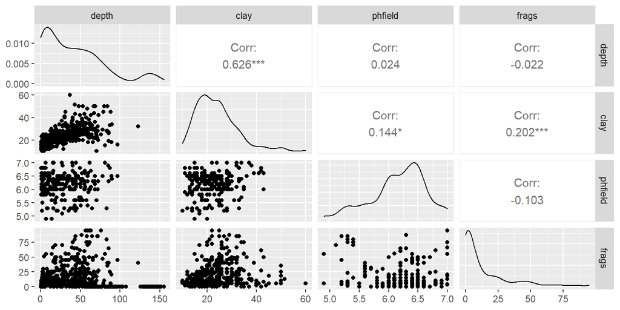

# ggplot2 basics

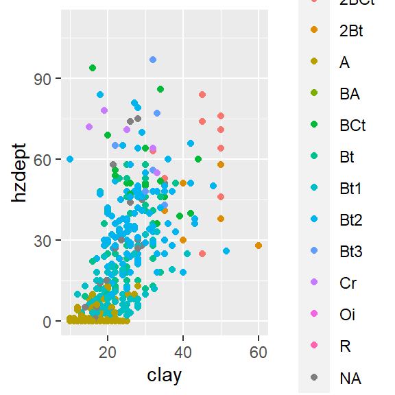

```r
h <- horizons(loafercreek)

# set figure axis and aesthetics
p <- ggplot(data = h, aes(x = clay, y = hzdept, color = genhz))

# add layers
p + geom_point()
```

# Summary of Components

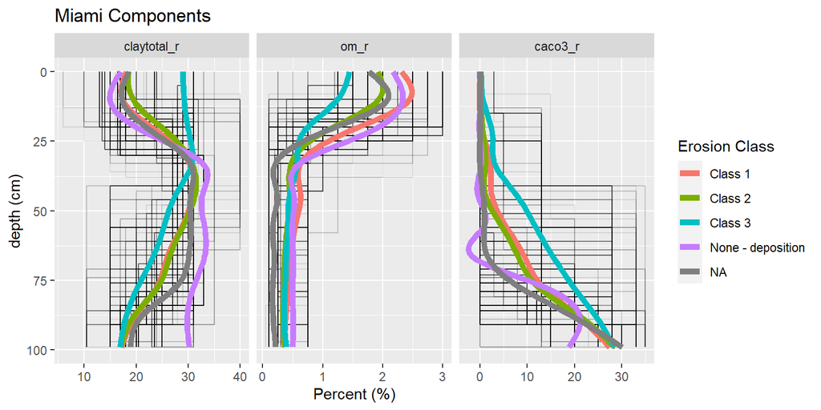

# Additional Reading

Healy, K., 2018. Data Visualization: a practical introduction. Princeton University Press. http://socviz.co/

Helsel, D.R., and R.M. Hirsch, 2002. Statistical Methods in Water Resources Techniques of Water Resources Investigations, Book 4, chapter A3. U.S. Geological Survey. 522 pages. http://pubs.usgs.gov/twri/twri4a3/

Kabacoff, R.I., 2015. R in Action. Manning Publications Co. Shelter Island, NY. https://www.statmethods.net/

Kabacoff, R.I., 2018. Data Visualization in R. https://rkabacoff.github.io/datavis/

Peng, R. D., 2016. Exploratory Data Analysis with R. Leanpub. https://bookdown.org/rdpeng/exdata/

Wilke, C.O., 2019. Fundamentals of Data Visualization. O’Reily Media, Inc. https://serialmentor.com/dataviz/